# **Stephen Olet (Task 3): Clustering based Course Recommender System**

Previously, we have generated user profile vectors based on course ratings and genres.

A user profile vector may look like a row vector in the following matrix, for example, we can see the Database column for user2 has a value 1 which means user2 is very interesting in courses related to the databases. With the user profile vectors generated, we can also easily compute the similarity among users based on their shared interests.

[figure not shown]

Furthermore, we could perform clustering algorithms such as K-means or DBSCAN to group users with similar learning interests. For example, in the below user clusters, we have user clusters whom have learned courses related to machine learning, cloud computing, databases, and web development, etc.

[figure not shown]

For each user group, we can come up with a list of popular courses. For example, for the machine learning user cluster/learning group, we can count the most frequently enrolled courses, which are very likely to be the most popular and good machine learning courses because they are enrolled by many users who are interested in machine learning.

If we know a user belongs to the machine learning group, we may recommend the most enrolled courses to them and it is very likely the user will be interested in them.

Next in this lab, you will be implementing some clustering-based recommender system algorithms.

## Objectives

After completing this lab you will be able to:

- Perform k-means clustering on the original user profile feature vectors
- Apply PCA (Principle Component Analysis ) on user profile feature vectors to reduce dimensions
- Perform k-means clustering on the PCA transformed main components
- Generate course recommendations based on other group members' enrollment history

## Prepare and setup lab environment

First install and import required libraries:

```python
%pip install scikit-learn
%pip install seaborn
%pip install pandas
%pip install matplotlib
```

```python
import seaborn as sns
import pandas as pd
import numpy as np
import matplotlib.pyplot as plt

from sklearn.cluster import KMeans
from sklearn.preprocessing import StandardScaler
from sklearn.decomposition import PCA

%matplotlib inline
```

```python
# also set a random state
rs = 123
```

### Load the user profile dataset

Let's first load the original user profile feature vectors:

```python
# Importing the pandas library, which is commonly used for data manipulation and analysis
import pandas as pd

# Defining the URL of the CSV file containing user profiles
user_profile_url = "https://cf-courses-data.s3.us.cloud-object-storage.appdomain.cloud/IBM-ML321EN-SkillsNetwork/labs/datasets/user_profile.csv"

# Using pandas' read_csv function to read the CSV file from the specified URL into a DataFrame
user_profile_df = pd.read_csv(user_profile_url)

# Displaying the first few rows of the DataFrame to inspect its contents
user_profile_df.head()
```

|  | user | Database | Python | CloudComputing | DataAnalysis | Containers | MachineLearning | ComputerVision | DataScience | BigData | Chatbot | R | BackendDev | FrontendDev | Blockchain |
| --- | --- | --- | --- | --- | --- | --- | --- | --- | --- | --- | --- | --- | --- | --- | --- |
| 0 | 2 | 52.0 | 14.0 | 6.0 | 43.0 | 3.0 | 33.0 | 0.0 | 29.0 | 41.0 | 2.0 | 18.0 | 34.0 | 9.0 | 6.0 |
| 1 | 4 | 40.0 | 2.0 | 4.0 | 28.0 | 0.0 | 14.0 | 0.0 | 20.0 | 24.0 | 0.0 | 6.0 | 6.0 | 0.0 | 2.0 |
| 2 | 5 | 24.0 | 8.0 | 18.0 | 24.0 | 0.0 | 30.0 | 0.0 | 22.0 | 14.0 | 2.0 | 14.0 | 26.0 | 4.0 | 6.0 |
| 3 | 7 | 2.0 | 0.0 | 0.0 | 2.0 | 0.0 | 0.0 | 0.0 | 0.0 | 2.0 | 0.0 | 0.0 | 0.0 | 0.0 | 0.0 |
| 4 | 8 | 6.0 | 0.0 | 0.0 | 4.0 | 0.0 | 0.0 | 0.0 | 0.0 | 6.0 | 0.0 | 2.0 | 0.0 | 0.0 | 0.0 |

```python
user_profile_df.shape
```

```
(33901, 15)
```

we can then list the feature names, they are the user interested topics (course genres):

```python
feature_names = list(user_profile_df.columns[1:])
feature_names
```

```
['Database',
 'Python',
 'CloudComputing',
 'DataAnalysis',
 'Containers',
 'MachineLearning',
 'ComputerVision',
 'DataScience',
 'BigData',
 'Chatbot',
 'R',
 'BackendDev',
 'FrontendDev',
 'Blockchain']
```

As we can see from the user profile dataset, we have about 33K unique users with interests in areas like `Database`, `Python`, `CloudComputing`, etc. Then, let's check the summary statistics for each feature.

```python
user_profile_df.describe()
```

|  | user | Database | Python | CloudComputing | DataAnalysis | Containers | MachineLearning | ComputerVision | DataScience | BigData | Chatbot | R | BackendDev | FrontendDev | Blockchain |
| --- | --- | --- | --- | --- | --- | --- | --- | --- | --- | --- | --- | --- | --- | --- | --- |
| count | 3.390100e+04 | 33901.000000 | 33901.000000 | 33901.000000 | 33901.000000 | 33901.000000 | 33901.000000 | 33901.000000 | 33901.000000 | 33901.000000 | 33901.000000 | 33901.000000 | 33901.000000 | 33901.000000 | 33901.000000 |
| mean | 1.064064e+06 | 5.518569 | 3.493791 | 2.307100 | 3.624701 | 0.998938 | 3.048022 | 0.001770 | 5.087343 | 4.750450 | 0.462995 | 1.017433 | 2.269461 | 0.315802 | 0.986844 |
| std | 4.972578e+05 | 7.611941 | 4.227254 | 3.841858 | 4.760135 | 2.351764 | 4.624004 | 0.072846 | 5.230697 | 7.216228 | 1.055186 | 2.342532 | 4.310752 | 1.363462 | 1.950585 |
| min | 2.000000e+00 | 0.000000 | 0.000000 | 0.000000 | 0.000000 | 0.000000 | 0.000000 | 0.000000 | 0.000000 | 0.000000 | 0.000000 | 0.000000 | 0.000000 | 0.000000 | 0.000000 |
| 25% | 6.813480e+05 | 0.000000 | 0.000000 | 0.000000 | 0.000000 | 0.000000 | 0.000000 | 0.000000 | 0.000000 | 0.000000 | 0.000000 | 0.000000 | 0.000000 | 0.000000 | 0.000000 |
| 50% | 1.043907e+06 | 3.000000 | 3.000000 | 0.000000 | 3.000000 | 0.000000 | 0.000000 | 0.000000 | 3.000000 | 2.000000 | 0.000000 | 0.000000 | 0.000000 | 0.000000 | 0.000000 |
| 75% | 1.451159e+06 | 9.000000 | 6.000000 | 3.000000 | 6.000000 | 0.000000 | 3.000000 | 0.000000 | 9.000000 | 6.000000 | 0.000000 | 0.000000 | 3.000000 | 0.000000 | 2.000000 |
| max | 2.103039e+06 | 63.000000 | 18.000000 | 38.000000 | 48.000000 | 15.000000 | 39.000000 | 3.000000 | 32.000000 | 54.000000 | 6.000000 | 18.000000 | 54.000000 | 15.000000 | 12.000000 |

The original user profile feature vector is not normalized, which may cause issues when we perform clustering and Principal component analysis (PCA), therefor we standardize the data.

```python
# Use StandardScaler to make each feature with mean 0, standard deviation 1
# Instantiating a StandardScaler object
scaler = StandardScaler()

# Standardizing the selected features (feature_names) in the user_profile_df DataFrame
user_profile_df[feature_names] = scaler.fit_transform(user_profile_df[feature_names])

# Printing the mean and standard deviation of the standardized features
print("mean {} and standard deviation{} ".format(user_profile_df[feature_names].mean(), user_profile_df[feature_names].std()))
```

```
mean Database          -3.353495e-17
Python            -5.700942e-17
CloudComputing    -3.521170e-17
DataAnalysis      -7.671120e-17
Containers         3.353495e-18
MachineLearning    3.688845e-17
ComputerVision    -1.509073e-17
DataScience       -1.676748e-17
BigData            6.706990e-17
Chatbot           -6.874665e-17
R                  4.233788e-17
BackendDev         1.383317e-17
FrontendDev        5.051202e-17
Blockchain        -5.281755e-17
dtype: float64 and standard deviationDatabase           1.000015
Python             1.000015
CloudComputing     1.000015
DataAnalysis       1.000015
Containers         1.000015
MachineLearning    1.000015
ComputerVision     1.000015
DataScience        1.000015
BigData            1.000015
Chatbot            1.000015
R                  1.000015
BackendDev         1.000015
FrontendDev        1.000015
Blockchain         1.000015
dtype: float64
```

```python
user_profile_df.describe()
```

|  | user | Database | Python | CloudComputing | DataAnalysis | Containers | MachineLearning | ComputerVision | DataScience | BigData | Chatbot | R | BackendDev | FrontendDev | Blockchain |
| --- | --- | --- | --- | --- | --- | --- | --- | --- | --- | --- | --- | --- | --- | --- | --- |
| count | 3.390100e+04 | 3.390100e+04 | 3.390100e+04 | 3.390100e+04 | 3.390100e+04 | 3.390100e+04 | 3.390100e+04 | 3.390100e+04 | 3.390100e+04 | 3.390100e+04 | 3.390100e+04 | 3.390100e+04 | 3.390100e+04 | 3.390100e+04 | 3.390100e+04 |
| mean | 1.064064e+06 | -3.353495e-17 | -5.700942e-17 | -3.521170e-17 | -7.671120e-17 | 3.353495e-18 | 3.688845e-17 | -1.509073e-17 | -1.676748e-17 | 6.706990e-17 | -6.874665e-17 | 4.233788e-17 | 1.383317e-17 | 5.051202e-17 | -5.281755e-17 |
| std | 4.972578e+05 | 1.000015e+00 | 1.000015e+00 | 1.000015e+00 | 1.000015e+00 | 1.000015e+00 | 1.000015e+00 | 1.000015e+00 | 1.000015e+00 | 1.000015e+00 | 1.000015e+00 | 1.000015e+00 | 1.000015e+00 | 1.000015e+00 | 1.000015e+00 |
| min | 2.000000e+00 | -7.249991e-01 | -8.265040e-01 | -6.005256e-01 | -7.614816e-01 | -4.247674e-01 | -6.591835e-01 | -2.429612e-02 | -9.726080e-01 | -6.583107e-01 | -4.387873e-01 | -4.343370e-01 | -5.264730e-01 | -2.316212e-01 | -5.059295e-01 |
| 25% | 6.813480e+05 | -7.249991e-01 | -8.265040e-01 | -6.005256e-01 | -7.614816e-01 | -4.247674e-01 | -6.591835e-01 | -2.429612e-02 | -9.726080e-01 | -6.583107e-01 | -4.387873e-01 | -4.343370e-01 | -5.264730e-01 | -2.316212e-01 | -5.059295e-01 |
| 50% | 1.043907e+06 | -3.308757e-01 | -1.168130e-01 | -6.005256e-01 | -1.312380e-01 | -4.247674e-01 | -6.591835e-01 | -2.429612e-02 | -3.990622e-01 | -3.811535e-01 | -4.387873e-01 | -4.343370e-01 | -5.264730e-01 | -2.316212e-01 | -5.059295e-01 |
| 75% | 1.451159e+06 | 4.573712e-01 | 5.928781e-01 | 1.803581e-01 | 4.990056e-01 | -4.247674e-01 | -1.038556e-02 | -2.429612e-02 | 7.480294e-01 | 1.731609e-01 | -4.387873e-01 | -4.343370e-01 | 1.694715e-01 | -2.316212e-01 | 5.194189e-01 |
| max | 2.103039e+06 | 7.551593e+00 | 3.431642e+00 | 9.290667e+00 | 9.322416e+00 | 5.953517e+00 | 7.775190e+00 | 4.115884e+01 | 5.145214e+00 | 6.824934e+00 | 5.247500e+00 | 7.249771e+00 | 1.200053e+01 | 1.076995e+01 | 5.646161e+00 |

The normalized user profile features are:

```python
features = user_profile_df.loc[:, user_profile_df.columns != 'user']
features
```

|  | Database | Python | CloudComputing | DataAnalysis | Containers | MachineLearning | ComputerVision | DataScience | BigData | Chatbot | R | BackendDev | FrontendDev | Blockchain |
| --- | --- | --- | --- | --- | --- | --- | --- | --- | --- | --- | --- | --- | --- | --- |
| 0 | 6.106474 | 2.485388 | 0.961242 | 8.272010 | 0.850889 | 6.477594 | -0.024296 | 4.571668 | 5.023412 | 1.456642 | 7.249771 | 7.360899 | 6.369323 | 2.570116 |
| 1 | 4.529980 | -0.353377 | 0.440653 | 5.120792 | -0.424767 | 2.368540 | -0.024296 | 2.851031 | 2.667576 | -0.438787 | 2.127032 | 0.865416 | -0.231621 | 0.519419 |
| 2 | 2.427988 | 1.066006 | 4.084776 | 4.280467 | -0.424767 | 5.828796 | -0.024296 | 3.233395 | 1.281790 | 1.456642 | 5.542191 | 5.505047 | 2.702132 | 2.570116 |
| 3 | -0.462250 | -0.826504 | -0.600526 | -0.341319 | -0.424767 | -0.659184 | -0.024296 | -0.972608 | -0.381153 | -0.438787 | -0.434337 | -0.526473 | -0.231621 | -0.505930 |
| 4 | 0.063248 | -0.826504 | -0.600526 | 0.078843 | -0.424767 | -0.659184 | -0.024296 | -0.972608 | 0.173161 | -0.438787 | 0.419453 | -0.526473 | -0.231621 | -0.505930 |
| ... | ... | ... | ... | ... | ... | ... | ... | ... | ... | ... | ... | ... | ... | ... |
| 33896 | -0.330876 | -0.116813 | 0.180358 | 0.499006 | -0.424767 | -0.659184 | -0.024296 | 0.174484 | -0.658311 | -0.438787 | 2.127032 | 0.865416 | -0.231621 | 1.032093 |
| 33897 | -0.724999 | -0.826504 | -0.079936 | -0.761482 | -0.424767 | -0.659184 | -0.024296 | -0.972608 | -0.658311 | -0.438787 | -0.434337 | -0.526473 | -0.231621 | -0.505930 |
| 33898 | -0.330876 | 0.592878 | 0.961242 | -0.761482 | -0.424767 | 2.368540 | -0.024296 | 0.748029 | -0.658311 | -0.438787 | 0.846348 | -0.526473 | -0.231621 | -0.505930 |
| 33899 | -0.724999 | -0.826504 | -0.600526 | -0.761482 | -0.424767 | -0.226652 | -0.024296 | -0.972608 | -0.658311 | -0.438787 | -0.434337 | -0.526473 | -0.231621 | -0.505930 |
| 33900 | -0.724999 | -0.826504 | -0.600526 | -0.761482 | -0.424767 | -0.226652 | -0.024296 | -0.972608 | -0.658311 | -0.438787 | -0.434337 | -0.526473 | -0.231621 | -0.505930 |

33901 rows × 14 columns

we can also save the user ids for later recommendation tasks:

```python
user_ids = user_profile_df.loc[:, user_profile_df.columns == 'user']
user_ids
```

|  | user |
| --- | --- |
| 0 | 2 |
| 1 | 4 |
| 2 | 5 |
| 3 | 7 |
| 4 | 8 |
| ... | ... |
| 33896 | 2102054 |
| 33897 | 2102356 |
| 33898 | 2102680 |
| 33899 | 2102983 |
| 33900 | 2103039 |

33901 rows × 1 columns

### TASK: Perform K-means clustering algorithm on the user profile feature vectors

With the user profile dataset ready, you need to use the `KMeans` class provided by scikit-learn library to perform clustering on the user profile feature vectors.

For `KMeans` algorithm, one important hyperparameter is the number of clusters `n_cluster`, and a good way to find the optimized `n_cluster` is using to grid search a list of candidates and find the one with the best or optimized clustering evaluation metrics such as minimal `sum of squared distance`:

*TODO: grid search the optimized n_cluster for KMeans() model*

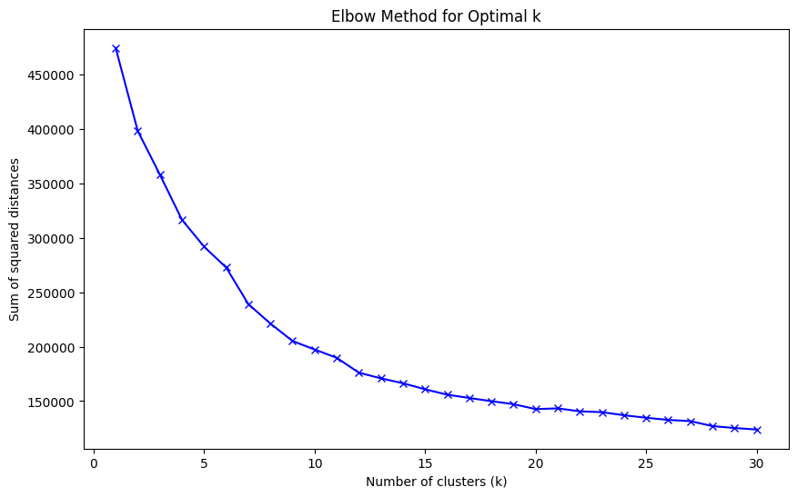

```
k=1: inertia=474614.0000000064
k=2: inertia=398238.15261968935
k=3: inertia=358159.52476682287
k=4: inertia=316594.05798040656
k=5: inertia=291908.37187780987
k=6: inertia=272759.59581968235
k=7: inertia=239164.2810184154
k=8: inertia=221242.0996245398
k=9: inertia=205215.3817634496
k=10: inertia=197392.96871753313
k=11: inertia=189765.3869509732
k=12: inertia=176117.79215551587
k=13: inertia=170861.81347858332
k=14: inertia=166366.15316720546
k=15: inertia=160791.2907027063
k=16: inertia=155870.95363213532
k=17: inertia=152813.93000066932
k=18: inertia=149874.74101289865
k=19: inertia=147147.11545651034
k=20: inertia=142593.9182914121
k=21: inertia=143290.75463919697
k=22: inertia=140552.1576577407
k=23: inertia=139776.7861359461
k=24: inertia=136951.229226211
k=25: inertia=134639.38388317951
k=26: inertia=132673.79186807753
k=27: inertia=131537.05528953118
k=28: inertia=126985.01658519861
k=29: inertia=125203.91633972444
k=30: inertia=123840.96638566192
```

```python
import numpy as np
import matplotlib.pyplot as plt
from sklearn.cluster import KMeans

# List of k values to try
list_k = list(range(1, 31))

# List to store the sum of squared distances (inertia) for each k
inertias = []

# Random state for reproducibility
rs = 42

# Perform KMeans clustering for each k and store the inertia
for k in list_k:
    model = KMeans(n_clusters=k, random_state=rs).fit(features)
    inertias.append(model.inertia_)

# Plot the elbow curve
plt.figure(figsize=(10, 6))
plt.plot(list_k, inertias, 'bx-')
plt.xlabel('Number of clusters (k)')
plt.ylabel('Sum of squared distances')
plt.title('Elbow Method for Optimal k')
plt.show()

# Print the inertia values
for k, inertia in zip(list_k, inertias):
    print(f"k={k}: inertia={inertia}")
```

**Click here for Hints**

Create a list that will hold the the sum of square distances for each fitted model. For each k in `n_clusters` make a model by calling `KMeans(n_clusters=k, random_state=rs).fit(features)` ans append `model.inertia_` to the list. Plot square distances against the k values.

If you plot the grid search process, you may get a elbow plot like the following:

[figure not shown]

From the elbow plot, you should visualy identify the point where the metric starting to be flatten, which indicates the optimized number of clusters.

Once you have identified the best number of clusters, you can apply `KMeans()` again to generate cluster label for all users.

```python
cluster_labels = [None] * len(user_ids)
```

_TODO: Apply KMeans() on the features with optimized n_cluster parameter after model fitting, you can find output cluster labels in `model.labels_` attribute_

```python
# Assuming we've determined the optimal number of clusters from the elbow plot
optimal_k = 10  # Replace this with the actual optimal k you've identified

# Create and fit the KMeans model with the optimal number of clusters
model = KMeans(n_clusters=optimal_k, random_state=42).fit(features)

# Get the cluster labels
cluster_labels = model.labels_

# Print the first few labels to verify
print("First few cluster labels:", cluster_labels[:10])

# Print the number of users in each cluster
unique, counts = np.unique(cluster_labels, return_counts=True)
for cluster, count in zip(unique, counts):
    print(f"Cluster {cluster}: {count} users")
```

```
First few cluster labels: [4 0 4 1 1 3 9 7 1 1]
Cluster 0: 1220 users
Cluster 1: 11029 users
Cluster 2: 570 users
Cluster 3: 4476 users
Cluster 4: 408 users
Cluster 5: 3141 users
Cluster 6: 20 users
Cluster 7: 6137 users
Cluster 8: 3001 users
Cluster 9: 3899 users
```

**Click here for Hints**

Create a model by calling `KMeans(n_clusters=k, random_state=rs).fit(features)`. Save the labels by accessing `model.labels`.

The cluster labels you generated is a list of integers indicating cluster indices. You may use the following utility method to combine the cluster labels and user ids to a dataframe, so that you know which cluster a user belongs:

```python
import pandas as pd

def combine_cluster_labels(user_ids, labels):
    # Convert labels to a DataFrame
    labels_df = pd.DataFrame(labels)
    # Merge user_ids DataFrame with labels DataFrame based on index
    cluster_df = pd.merge(user_ids, labels_df, left_index=True, right_index=True)
    # Rename columns to 'user' and 'cluster'
    cluster_df.columns = ['user', 'cluster']
    return cluster_df

# Assuming we have already generated cluster_labels from the KMeans model
# and user_ids is the DataFrame containing user IDs

# Combine user IDs and cluster labels
user_cluster_df = combine_cluster_labels(user_ids, cluster_labels)

# Display the resulting DataFrame
print(user_cluster_df)
```

```
          user  cluster
0            2        4
1            4        0
2            5        4
3            7        1
4            8        1
...        ...      ...
33896  2102054        5
33897  2102356        1
33898  2102680        7
33899  2102983        1
33900  2103039        1

[33901 rows x 2 columns]
```

Your clustering results may look like the following screenshot:

[figure not shown]

Now, each user finds its own cluster or we can say we have created many clusters of learning communities. Learners within each community share very similar learning interests.

### TASK: Apply PCA on user profile feature vectors to reduce dimensions

In the previous step, we applied `KMeans` on the original user profile feature vectors which have 14 original features (the course genres).

```python
# Extracting features from the user_profile_df DataFrame, excluding the 'user' column
features = user_profile_df.loc[:, user_profile_df.columns != 'user']

# Extracting user IDs from the user_profile_df DataFrame
user_ids = user_profile_df.loc[:, user_profile_df.columns == 'user']

# Creating a list of feature names by excluding the 'user' column name
feature_names = list(user_profile_df.columns[1:])
```

```python
print(f"There are {len(feature_names)} features for each user profile.")
```

```
There are 14 features for each user profile.
```

If we plot a covariance matrix of the user profile feature vectors with 14 features, we can observe that some features are actually correlated:

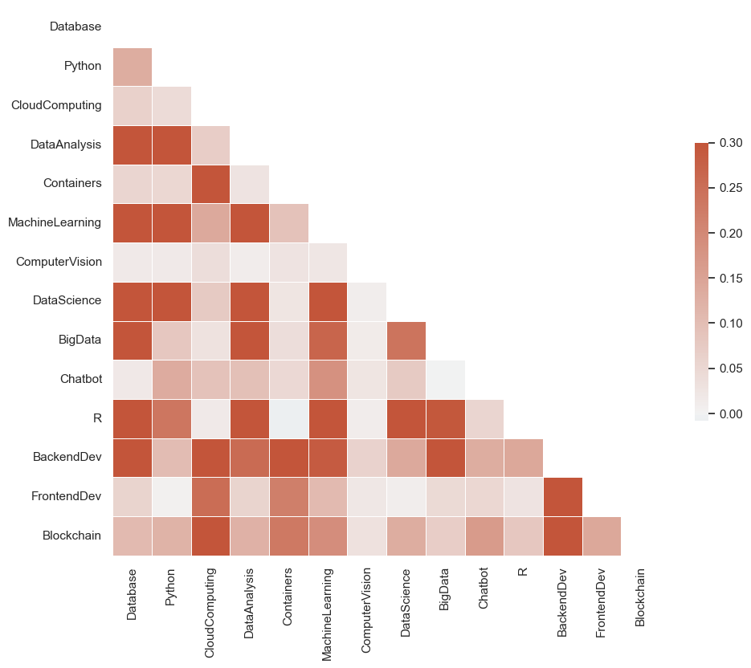

```python
sns.set_theme(style="white")

# Compute the correlation matrix
corr = features.cov()

# Generate a mask for the upper triangle
mask = np.triu(np.ones_like(corr, dtype=bool))

# Set up the matplotlib figure
f, ax = plt.subplots(figsize=(11, 9))

# Generate a custom diverging colormap
cmap = sns.diverging_palette(230, 20, as_cmap=True)

# Draw the heatmap with the mask and correct aspect ratio
sns.heatmap(corr, mask=mask, cmap=cmap, vmax=.3, center=0,
            square=True, linewidths=.5, cbar_kws={"shrink": .5})


plt.show()
```

For example, the feature `MachineLearning` and the feature `DataScience` are correlated. Such covariances among features may indicate that we can apply PCA to find its main components (eigenvectors with max eigenvalues on the covariance matrix).

If we only keep the independent main components, then we can reduce the dimensions of our user profile feature vectors.

Now let's apply the `PCA()` provided by `scikit-learn` to find the main components in user profile feature vectors and see if we can reduce its dimensions by only keeping the main components.

Note that when calling the `PCA()` class, there is also an import argument called `n_components` which indicates how many components you want to keep in the PCA result. One way to find an optimized `n_components` is to do a grid search on a list of argument candidates (such as `range(1, 15)`) and calculate the ratio of the accumulated variance for each candidate.

If the accumulated variances ratio of a candidate `n_components` is larger than a threshold, e.g., 90%, then we can say the transformed `n_components` could explain about 90% of variances of the original data variance and can be considered as an optimized components size.

*TODO: Find the optimized `n_components` for PCA*

```python
from sklearn.decomposition import PCA

# List to store the accumulated variance ratios for each number of components
accumulated_variance_ratios = []

# Iterate over each possible number of components
for n_components in range(1, 15):
    # Create and fit the PCA model
    pca = PCA(n_components=n_components)
    pca.fit(features)

    # Calculate the accumulated variance ratio
    accumulated_variance = sum(pca.explained_variance_ratio_)
    accumulated_variance_ratios.append(accumulated_variance)

    # Print the accumulated variance ratio
    print(f"n_components={n_components}: accumulated variance={accumulated_variance:.4f}")

# Find the smallest n_components value that explains at least 90% of the variance
optimal_n_components = next(i for i, accumulated_variance in enumerate(accumulated_variance_ratios, start=1) if accumulated_variance >= 0.9)

print(f"The optimal number of components that explains at least 90% of the variance is: {optimal_n_components}")
```

```
n_components=1: accumulated variance=0.2876
n_components=2: accumulated variance=0.4631
n_components=3: accumulated variance=0.5761
n_components=4: accumulated variance=0.6487
n_components=5: accumulated variance=0.7195
n_components=6: accumulated variance=0.7882
n_components=7: accumulated variance=0.8430
n_components=8: accumulated variance=0.8944
n_components=9: accumulated variance=0.9273
n_components=10: accumulated variance=0.9545
n_components=11: accumulated variance=0.9734
n_components=12: accumulated variance=0.9870
n_components=13: accumulated variance=0.9979
n_components=14: accumulated variance=1.0000
The optimal number of components that explains at least 90% of the variance is: 9
```

**Click here for Hints**

- For each `n_components` from 1 to 14 you can call `PCA=PCA(n_components=component)`, then you can simply fit it by callsing `pca.fit_transform(features)` where `features = user_profile_df.loc[:, user_profile_df.columns != 'user']`.
- Then you can find `accumulated_variance_ratios` by applying `sum()` to `pca.explained_variance_ratio_`.
- Then find the smallest n_components value for which `accumulated_variance_ratios >= 0.9` and return it.

If you visualize your hyperparameter searching process, you may get a trend line like the following:

[figure not shown]

Once you found the optimized `n_component` argument value, you can apply PCA on the user profile feature vectors and reduce the 14 features into `n_component` features.

*TODO: Perform PCA to transform original user profile features*

```python
import pandas as pd
from sklearn.decomposition import PCA

# Assume features is defined as all columns except 'user'
features = user_profile_df.loc[:, user_profile_df.columns != 'user']

# Find the optimal number of components that explains at least 90% of the variance
optimal_n_components = 0
accumulated_variance = 0
for n_components in range(1, 15):
    pca = PCA(n_components=n_components)
    pca.fit(features)
    accumulated_variance = sum(pca.explained_variance_ratio_)
    if accumulated_variance >= 0.9:
        optimal_n_components = n_components
        break

print(f"The optimal number of components is: {optimal_n_components}")

# Perform PCA with the optimal number of components
pca = PCA(n_components=optimal_n_components)
components = pca.fit_transform(features)

# Create a DataFrame for the transformed components
components_df = pd.DataFrame(data=components, index=user_profile_df.index)

# Merge the user IDs with the transformed features
result_df = pd.merge(user_profile_df[['user']], components_df, left_index=True, right_index=True)

# Display the result
print(result_df.head())
```

```
The optimal number of components is: 9
   user          0         1         2         3         4         5  \
0     2  17.772494  0.200681  1.730609  2.567359 -3.825814 -2.707154
1     4   7.145199 -2.847481  2.358636 -0.576654  0.398803  0.134533
2     5  11.363270  1.873619 -1.522077  1.076144 -1.711688 -0.883212
3     7  -1.834033 -0.277462  0.564905  0.053470 -0.064440 -0.165757
4     8  -1.049125 -0.684767  1.072765  0.006371 -0.005695 -0.118686

          6         7         8
0  0.681042  2.312613  0.868272
1  0.549769  0.469033  0.033405
2  1.677582  2.937669  2.097639
3  0.030956  0.039519  0.210887
4  0.118559  0.559292  0.186379
```

**Click here for Hints**

- Call PCA class as `pca = PCA(n_components=n_components)`
- Fit PCA model using predefined `features` variable as only parameter
- Get the components by calling `pca.fit_transform(features)`
- Create a `pd.DataFrame(data=components)` and use `pd.merge` to merge it with `user_ids` don't forget to specify `left_index=True, right_index=True` in `merge` function parameters.

Your PCA transformed dataframe may look like the following:

[figure not shown]

### TASK: Perform k-means clustering on the PCA transformed feature vectors

Now, you have the PCA components of the original profile vectors. You can perform k-means on them again:

*TODO: Perform K-means on the PCA transformed features*

```python
import pandas as pd
from sklearn.decomposition import PCA
from sklearn.cluster import KMeans

# Assuming you have a DataFrame 'user_profile_df' with user profile features
# and a column 'user' for user IDs

# Define the features (excluding the 'user' column)
features = user_profile_df.loc[:, user_profile_df.columns != 'user']

# Perform PCA to find the optimal number of components
explained_variance_ratio = []
for n in range(1, 15):
    pca = PCA(n_components=n)
    pca.fit(features)
    explained_variance_ratio.append(sum(pca.explained_variance_ratio_))

# Find the minimal number of components that explain at least 90% variance
optimal_n_components = next(n for n, variance in enumerate(explained_variance_ratio, start=1) if variance >= 0.9)

# Transform the features using PCA
pca = PCA(n_components=optimal_n_components)
pca_features = pca.fit_transform(features)

# Apply K-means clustering
kmeans = KMeans(n_clusters=5, random_state=42)  # You can choose a different number of clusters
kmeans.fit(pca_features)

# Get the cluster labels
cluster_labels = kmeans.labels_

# Combine user IDs and cluster labels
user_ids = user_profile_df[['user']]  # Extract the user IDs
clustered_users_df = combine_cluster_labels(user_ids, cluster_labels)

# Display rows of the combined DataFrame
print(clustered_users_df)
```

```
          user  cluster
0            2        0
1            4        0
2            5        0
3            7        4
4            8        4
...        ...      ...
33896  2102054        1
33897  2102356        4
33898  2102680        1
33899  2102983        4
33900  2103039        4

[33901 rows x 2 columns]
```

Your clustering results should have the same format as the k-means on the original dataset:

[figure not shown]

Great, now all users find their learning interest groups, either based on their original or the PCA transformed user profile features.

When a user is in a group or a community, it is very likely that the user will be interested in the courses enrolled by other members within the same group.

### TASK: Generate course recommendations based on the popular courses in the same cluster

The Intuition of clustering-based course recommendation is very simple and can be illustrated via the following example:

Suppose a user has joined a machine learning group (via clustering algorithm). In the group, he/she finds that the top-3 courses enrolled by all other group members are `Machine Learning for Everyone`, `Machine Learning with Python`, `Machine Learning with Scikit-learn`. Since the user has already completed the `Machine Learning for Everyone` earlier, he/she decides to trust the group members' choices and enroll in other two unselected courses `Machine Learning with Python` and `Machine Learning with Scikit-learn`.

In summary, the clustering-based recommender system first groups all users based on their profiles, and maintains a popular courses list for each group.

For any group member who needs course recommendations, the algorithm recommends the unselected courses from the popular course lists.

Next, suppose we have a set of test users, and we want to recommend new courses to them using a clustering-based recommender system:

```python
test_user_url = "https://cf-courses-data.s3.us.cloud-object-storage.appdomain.cloud/IBMSkillsNetwork-ML0321EN-Coursera/labs/v2/module_3/ratings.csv"

# Reading the test user data CSV file into a pandas DataFrame
# Selecting only the 'user' and 'item' columns using indexing
test_users_df = pd.read_csv(test_user_url)[['user', 'item']]

# Displaying the first few rows of the DataFrame to inspect its contents
test_users_df.head()
```

|  | user | item |
| --- | --- | --- |
| 0 | 1889878 | CC0101EN |
| 1 | 1342067 | CL0101EN |
| 2 | 1990814 | ML0120ENv3 |
| 3 | 380098 | BD0211EN |
| 4 | 779563 | DS0101EN |

The test users dataset has only two columns, the user id and the enrolled course id.

For each user, let's find its cluster label using the k-means results you have performed in previous steps, assuming it is named `cluster_df`.

You can assign the cluster label to all test users via merging the clustering labels (`cluster_df`:):

```python
import pandas as pd

# Assuming cluster_df contains the clustering results with user IDs and cluster labels
# For example, cluster_df should have columns: 'user' and 'cluster_label'

# Read test user data
test_user_url = "https://cf-courses-data.s3.us.cloud-object-storage.appdomain.cloud/IBMSkillsNetwork-ML0321EN-Coursera/labs/v2/module_3/ratings.csv"
test_users_df = pd.read_csv(test_user_url)[['user', 'item']]

# Merge with cluster labels
test_users_labelled = pd.merge(test_users_df, clustered_users_df, on='user')

# Display the first few rows to check the merged results
print(test_users_labelled)
```

```
           user        item  cluster
0       1889878    CC0101EN        0
1       1342067    CL0101EN        3
2       1990814  ML0120ENv3        0
3        380098    BD0211EN        0
4        779563    DS0101EN        1
...         ...         ...      ...
233301  1540125    DS0101EN        3
233302  1250651    PY0101EN        4
233303  1003832  CB0105ENv1        2
233304   922065    BD0141EN        3
233305  1596120    DS0301EN        1

[233306 rows x 3 columns]
```

The merged the test dataset may look like the following:

[figure not shown]

From the above dataframe, we know each user's enrolled courses and its cluster index.

If we use a `groupby` and `sum` aggregation, we can get the enrollments count for each course in each group, like the following code snippet:

```python
# Extracting the 'item' and 'cluster' columns from the test_users_labelled DataFrame
courses_cluster = test_users_labelled[['item', 'cluster']]

# Adding a new column 'count' with a value of 1 for each row in the courses_cluster DataFrame
courses_cluster['count'] = [1] * len(courses_cluster)

# Grouping the DataFrame by 'cluster' and 'item', aggregating the 'count' column with the sum function,
# and resetting the index to make the result more readable
courses_cluster_grouped = courses_cluster.groupby(['cluster','item']).agg(enrollments=('count','sum')).reset_index()
```

*TODO: For each test user, try to recommend any unseen courses based on the popular courses in his/her cluster. You may use an enrollment count threshold (such as larger than 10) to determine if it is a popular course in the cluster*

```python
import pandas as pd

# Assuming test_users_labelled and courses_cluster_grouped are already available

def recommend_courses_for_user(user_id, courses_cluster_grouped, test_users_labelled, threshold=10):
    # Get the user's data
    user_subset = test_users_labelled[test_users_labelled['user'] == user_id]

    # If the user is not in the dataset, return an empty list
    if user_subset.empty:
        return []

    # Get the user's cluster label and enrolled courses
    cluster_label = user_subset['cluster'].iloc[0]
    enrolled_courses = set(user_subset['item'])

    # Get all courses in the same cluster
    cluster_courses = courses_cluster_grouped[courses_cluster_grouped['cluster'] == cluster_label]

    # Filter popular courses based on the threshold
    popular_courses = cluster_courses[cluster_courses['enrollments'] > threshold]

    # Find new/unseen courses
    popular_courses_list = set(popular_courses['item'])
    unseen_courses = popular_courses_list.difference(enrolled_courses)

    # Create a list of recommended courses
    recommendations = list(unseen_courses)

    return recommendations

# Example usage for a test user
user_id = 1889878  # Replace with the user ID you want to test
recommended_courses = recommend_courses_for_user(user_id, courses_cluster_grouped, test_users_labelled)

print(f"Recommended courses for user {user_id}: {recommended_courses}")
```

[output not shown]

**Click here for Hints**

- First of all, create a `user_subset` of `test_users_labelled` where `test_users_labelled['user'] == user_id`.
- Get the enrolled courses by simply accessing `['item']` column of `user_subset`
- Find its cluster label by accessing `['cluster']` column of `user_subset`. You can just use the first one (`.iloc[0]`) since every value in the column is the same for an individual user.
- You can find all courses in the same cluster, by simply accessing `['item']` column of a subset of `test_users_labelled` where `test_users_labelled[test_users_labelled['cluster'] == cluster_id]`
- You can find new/unseen courses to the user by taking a set difference between courses in cluster and enrolled_courses by using `.difference` method (dont forget to convert 2 lists in to sets before calling the method).
- Use `courses_cluster` data set to find popularity of new/unseen courses and make unseen and popular courses as recommendation results for the user

With the recommendation results, you also need to write some analytic code to answer the following two questions:

- On average, how many new/unseen courses have been recommended to each user?

```python
import pandas as pd

# Define the function to recommend courses for each user
def recommend_courses_for_user(user_id, courses_cluster_grouped, test_users_labelled, threshold=10):
    user_subset = test_users_labelled[test_users_labelled['user'] == user_id]

    if user_subset.empty:
        return []

    cluster_label = user_subset['cluster'].iloc[0]
    enrolled_courses = set(user_subset['item'])

    cluster_courses = courses_cluster_grouped[courses_cluster_grouped['cluster'] == cluster_label]
    popular_courses = cluster_courses[cluster_courses['enrollments'] > threshold]

    popular_courses_list = set(popular_courses['item'])
    unseen_courses = popular_courses_list.difference(enrolled_courses)

    recommendations = list(unseen_courses)

    return recommendations

# Get a list of all unique user IDs from the test_users_labelled DataFrame
user_ids = test_users_labelled['user'].unique()

# Generate recommendations for all users
recommendations_per_user = {}
for user_id in user_ids:
    recommendations = recommend_courses_for_user(user_id, courses_cluster_grouped, test_users_labelled)
    recommendations_per_user[user_id] = len(recommendations)

# Convert the dictionary to a DataFrame
recommendations_df = pd.DataFrame(list(recommendations_per_user.items()), columns=['user', 'num_recommendations'])

# Calculate the average number of recommended courses
average_recommendations = recommendations_df['num_recommendations'].mean()

print(f"On average, each user has been recommended {average_recommendations:.2f} new/unseen courses.")
```

```
On average, each user has been recommended 87.44 new/unseen courses.
```

- What are the most frequently recommended courses? Return the top-10 commonly recommended courses across all users.

```python
import pandas as pd
from collections import Counter

# Define the function to recommend courses for each user
def recommend_courses_for_user(user_id, courses_cluster_grouped, test_users_labelled, threshold=10):
    user_subset = test_users_labelled[test_users_labelled['user'] == user_id]

    if user_subset.empty:
        return []

    cluster_label = user_subset['cluster'].iloc[0]
    enrolled_courses = set(user_subset['item'])

    cluster_courses = courses_cluster_grouped[courses_cluster_grouped['cluster'] == cluster_label]
    popular_courses = cluster_courses[cluster_courses['enrollments'] > threshold]

    popular_courses_list = set(popular_courses['item'])
    unseen_courses = popular_courses_list.difference(enrolled_courses)

    recommendations = list(unseen_courses)

    return recommendations

# Get a list of all unique user IDs from the test_users_labelled DataFrame
user_ids = test_users_labelled['user'].unique()

# Generate recommendations for all users and aggregate them
all_recommendations = []
for user_id in user_ids:
    recommendations = recommend_courses_for_user(user_id, courses_cluster_grouped, test_users_labelled)
    all_recommendations.extend(recommendations)

# Count the frequency of each recommended course
course_frequency = Counter(all_recommendations)

# Convert the Counter object to a DataFrame for easy sorting
course_frequency_df = pd.DataFrame(course_frequency.items(), columns=['course', 'frequency'])

# Sort by frequency in descending order and get the top 10 most common courses
top_10_courses = course_frequency_df.sort_values(by='frequency', ascending=False).head(10)

print("Top 10 most frequently recommended courses:")
print(top_10_courses)
```

```
Top 10 most frequently recommended courses:
        course  frequency
61    CB0101EN      33678
59  ML0120ENv3      33596
67    DJ0101EN      33538
18    BD0153EN      33515
21    DS0201EN      33495
10    EE0101EN      33477
3     IT0101EN      33443
54    ML0111EN      33438
79    DE0205EN      33416
92    CC0250EN      33403
```

For example, suppose we have only 3 test users, each user receives the following recommendations:

- User1: ['course1', 'course2']
- User2: ['course3', 'course4']
- User3: ['course3', 'course4', 'course5']

Then, the average recommended courses per user is $(2 + 2 + 3) / 3 = 2.33$. The top-2 recommended courses are: `course3`: 2 times, and `course4`: 2 times.

Note that the answers will depend on how you compute the popular courses for each cluster. A lower threshold yields more recommended courses but with smaller confidence so that some test users may receive very long course recommendation lists and feel overwhelmed.

Ideally, we should limit the maximum course recommendations for each user to be less than 20 courses per user.

### Explore other clustering algorithms

As you have learned in previous unsupervised learning course, there are many other clustering algorithms such as `DBSCAN` and `Hierarchical Clustering`. You are encouraged to try them on the user profile feature vectors and compare the results with K-means.

### Summary

Congratulations! In this lab, you have applied clustering algorithms to group users with similar interests and also tried PCA to reduce the dimensions of user feature vectors.

Furthermore, with each user finding its learning interest group, you have also implemented clustering-based course recommender system to make recommendations based on his/her group members' popular courses choices.